[figure not shown]

# Couleur des yeux : Comment elle se développe et pourquoi elle change

Par [Gary Heiting, OD](https://www.allaboutvision.com/masthead-gary-heiting.htm), et [Adam Debrowski](https://www.allaboutvision.com/masthead-adam-debrowski.htm)

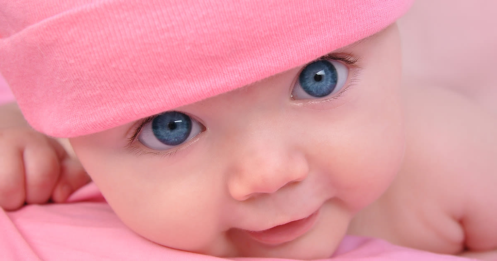

La couleur des yeux est souvent le trait génétique qui fascine le plus les parents au cours du développement de l’enfant. L’enfant aura-t-il des yeux noirs, bruns, bleus, gris, verts, noisette ou de couleurs mixtes?

L’apparence d’un enfant dépend du matériel génétique que chaque parent lui apporte. Mais les gènes des parents peuvent se combiner de différentes manières. Les facteurs d’influence de chaque parent ne sont connus qu’après la naissance de l’enfant.

## Comment la couleur de l’œil se développe

La partie colorée de [l’œil](https://www.allaboutvision.com/fr-ca/anatomie-oeil/structure-oeil/) se nomme [l’iris](https://www.allaboutvision.com/fr-ca/anatomie-oeil/uvee-iris-choroide/), qui a la pigmentation qui détermine la couleur de nos yeux.

La couleur des yeux humains est issue de trois gènes, dont deux sont bien connus. Ces gènes sont à l’origine des couleurs les plus courantes, le vert, le brun et le bleu. D’autres couleurs, telles que le gris, le noisette et de multiples combinaisons ne sont pas entièrement comprises ou explicables à l’heure actuelle.

À une époque, [la couleur brune des yeux](https://www.allaboutvision.com/fr-ca/ressources/yeux-bruns/) était considérée comme un trait "dominant" et [la couleur bleue des yeux](https://www.allaboutvision.com/fr-ca/ressources/yeux-bleus/) était considérée comme un trait "récessif". Mais la science moderne a montré que le processus de coloration des yeux n’est pas si simple.

La couleur des yeux n’est pas un simple mélange des couleurs des yeux des parents, comme on mélangerait de la peinture. Chaque parent possède deux paires de gènes sur chaque chromosome, et il existe de multiples possibilités quant à la manière dont cette information génétique s’exprime à travers la couleur des yeux.

Et très tôt dans la vie, la couleur des yeux peut changer.

La plupart des bébés caucasiens naissent avec des yeux bleus, qui peuvent ensuite s’assombrir au cours des trois premières années de leur vie. Le phénomène d’assombrissement se produit lorsque la mélanine, un pigment brun généralement absent à la naissance, se développe avec l’âge.

Il se peut que la couleur des yeux des enfants soit complètement différente de celle de leurs parents. Mais si les deux parents ont les yeux bruns, il est très probable que leurs enfants auront aussi les yeux bruns.

Les couleurs les plus foncées ont tendance à dominer, donc le brun a tendance à l’emporter sur le vert, et le vert a tendance à l’emporter sur le bleu.

Cependant, un scénario dans lequel un parent a les yeux bruns et l’autre les yeux bleus ne génère pas nécessairement un enfant aux yeux bruns.

Certains enfants naissent avec des iris dont les couleurs ne correspondent pas. En général, cette affection, appelée hétérochromie, est due à un défaut de transport des pigments au cours du développement, à un traumatisme local, soit dans l’utérus, soit peu après la naissance, ou à un trouble génétique bénin.

D’autres causes sont l’inflammation, la tache de rousseur (le naevus diffus) de l’iris et le syndrome de Horner.

Si vous remarquez que vos yeux ont une apparence inhabituelle, ne tardez pas à consulter votre professionnel des soins de la vue.

## Changements dans la couleur des yeux

L’iris est un muscle qui s’étend et se contracte pour contrôler [la taille de](https://www.allaboutvision.com/fr-ca/anatomie-oeil/pupille/) la pupille. La pupille s’agrandit lorsque l’éclairage est faible et se rétrécit lorsque l’éclairage est fort. La pupille se rétrécit également lorsque vous vous concentrez sur des objets rapprochés, comme un livre que vous seriez en train de lire.

Lorsque la taille de la pupille change, les pigments de l’iris se compriment ou se dilatent, ce qui modifie un peu la couleur de l’œil.

Certaines émotions peuvent également modifier la taille des pupilles et la couleur de l’iris. C’est pourquoi certaines personnes disent que leurs yeux changent de couleur quand ils sont en colère ou amoureux.

La couleur des yeux peut également changer avec l’âge. Cela se produit chez 10 à 15 % de la population caucasienne (personnes dont la couleur des yeux est généralement plus claire).

Par exemple, mes yeux qui étaient autrefois très bruns sont maintenant de couleur noisette, soit une combinaison de brun et de vert. Cependant, certains [yeux noisette](https://www.allaboutvision.com/fr-ca/anatomie-oeil/yeux-de-couleur-noisette/) prennent un aspect plus foncé avec l’âge.

Si la couleur de vos yeux d’adulte change de façon assez prononcée, ou si un œil passe du brun au vert ou du bleu au brun, il est important de consulter votre professionnel des soins de la vue.

Les changements de couleur des yeux peuvent être un signe d’alerte de certaines maladies, comme l’iridocyclite hétérochromique de Fuchs, le syndrome de Horner ou [glaucome pigmentaire](https://www.allaboutvision.com/fr-ca/conditions/glaucome/).

Page publiée dans mardi 24 août 2021

[figure not shown]

[figure not shown]

[figure not shown]

[figure not shown]

[figure not shown]

[figure not shown]

[figure not shown]